# Homework 03

## Question 1: Build an `explain-to-me` skill

I wrote `explain-to-me/SKILL.md` (reproduced in full at the end of this document): a short intent statement plus five rules — read only the one question I name, explain its goal and what’s given vs. needed, flag easy-to-miss requirements, point to the two Week 3 ridge lecture pages when relevant, and never write code, a derivation, or the answer. I installed it as a project skill at `.claude/skills/explain-to-me/SKILL.md`.

I tested it by asking the agent to use `explain-to-me` on Question 2. It correctly explained the goal (show why ridge stabilizes near-collinear coefficients), what’s given versus what I still had to produce for parts (a)-(c), the easy-to-miss requirements (the lecture’s specific standardization convention, reusing one noise draw across all three $\lambda$’s), and pointed me to the relevant lecture section — all without writing any code or stating a number. It didn’t disturb my workflow, so I kept it.

## Question 2: Ridge regression with nearly collinear predictors

**Show the workflow**

```python
import numpy as np
import matplotlib.pyplot as plt

np.random.seed(43231)
n = 100

L = np.random.normal(size=n)
U1 = np.random.normal(size=n)
U2 = np.random.normal(size=n)
X3 = np.random.normal(size=n)
X4 = np.random.normal(size=n)
X1 = L + 0.04 * U1
X2 = L + 0.04 * U2
X_raw = np.column_stack([X1, X2, X3, X4])

def standardize(A):
    # mean zero, average squared value one (population scaling)
    mean = A.mean(axis=0)
    Ac = A - mean
    scale = np.sqrt((Ac ** 2).mean(axis=0))
    return Ac / scale

X = standardize(X_raw)
p = X.shape[1]
beta_true = np.array([1.5, 1.5, 1.0, 0.0])
mu = X @ beta_true
```

**Show the workflow**

```python
corr12 = np.corrcoef(X[:, 0], X[:, 1])[0, 1]
svals = np.linalg.svd(X, compute_uv=False)

print("Correlation between X1 and X2:", round(corr12, 4))
print("Singular values:", np.round(svals, 4))
print("Largest singular value:", round(svals.max(), 4))
print("Smallest singular value:", round(svals.min(), 4))
```

```
Correlation between X1 and X2: 0.9983
Singular values: [14.1512 10.1831  9.7917  0.4135]
Largest singular value: 14.1512
Smallest singular value: 0.4135
```

$X_1,X_2$ are almost perfectly correlated ($\approx0.998$) since both are dominated by the shared factor $L_i$. The large singular value ($\approx14.15$) corresponds to the strong-signal $X_1+X_2$ direction; the small one ($\approx0.41$) corresponds to the near-noise-only $X_1-X_2$ direction. Since OLS variance scales with the inverse squared singular value, $\widehat\beta_1-\widehat\beta_2$ should be roughly $(14.15/0.41)^2\approx1190$ times more variable than $\widehat\beta_1+\widehat\beta_2$.

**Show the workflow**

```python
lambdas = [0.0, 0.02, 0.2]
n_sims = 200
results = {lam: {"b1": [], "b2": [], "sum": [], "diff": [],
                  "train_mse": [], "test_mse": []} for lam in lambdas}

for s in range(n_sims):
    eps = np.random.normal(size=n)
    eps_star = np.random.normal(size=n)
    y = mu + eps
    y_star = mu + eps_star
    ybar = y.mean()
    ytilde = y - ybar
    for lam in lambdas:
        beta_hat = np.linalg.solve(X.T @ X + n * lam * np.eye(p), X.T @ ytilde)
        fitted = ybar + X @ beta_hat
        r = results[lam]
        r["b1"].append(beta_hat[0])
        r["b2"].append(beta_hat[1])
        r["sum"].append(beta_hat[0] + beta_hat[1])
        r["diff"].append(beta_hat[0] - beta_hat[1])
        r["train_mse"].append(np.mean((y - fitted) ** 2))
        r["test_mse"].append(np.mean((y_star - fitted) ** 2))

for lam in lambdas:
    r = results[lam]
    print(f"\nlambda = {lam}")
    for key in ["b1", "b2", "sum", "diff"]:
        arr = np.array(r[key])
        print(f"  {key}: mean={arr.mean():.4f}, sd={arr.std(ddof=1):.4f}")
    print(f"  average training MSE = {np.mean(r['train_mse']):.4f}")
    print(f"  average test MSE     = {np.mean(r['test_mse']):.4f}")
```

```
lambda = 0.0
  b1: mean=1.4482, sd=1.6289
  b2: mean=1.5505, sd=1.6295
  sum: mean=2.9987, sd=0.0919
  diff: mean=-0.1023, sd=3.2570
  average training MSE = 0.9332
  average test MSE     = 1.0475

lambda = 0.02
  b1: mean=1.4827, sd=0.1357
  b2: mean=1.4871, sd=0.1364
  sum: mean=2.9698, sd=0.0910
  diff: mean=-0.0044, sd=0.2565
  average training MSE = 0.9421
  average test MSE     = 1.0402

lambda = 0.2
  b1: mean=1.3674, sd=0.0438
  b2: mean=1.3649, sd=0.0441
  sum: mean=2.7323, sd=0.0835
  diff: mean=0.0025, sd=0.0276
  average training MSE = 1.0420
  average test MSE     = 1.1328
```

## Question 3: What does ridge regression shrink?

1. Differentiating $L_\lambda(\boldsymbol\beta)=\frac{1}{2n}\lVert\widetilde{\mathbf y}-\mathbf X\boldsymbol\beta\rVert_2^2+\frac{\lambda}{2}\lVert\boldsymbol\beta\rVert_2^2$ and setting the gradient to zero,
   $$-\frac{1}{n}\mathbf X^{\mathsf T}(\widetilde{\mathbf y}-\mathbf X\boldsymbol\beta)+\lambda\boldsymbol\beta=\mathbf 0
   \quad\Longrightarrow\quad
   \left(\frac{1}{n}\mathbf X^{\mathsf T}\mathbf X+\lambda\mathbf I_p\right)\boldsymbol\beta=\frac{1}{n}\mathbf X^{\mathsf T}\widetilde{\mathbf y},$$
   and multiplying by $n$ gives $(\mathbf X^{\mathsf T}\mathbf X+n\lambda\mathbf I_p)\widehat{\boldsymbol\beta}_\lambda=\mathbf X^{\mathsf T}\widetilde{\mathbf y}$. $\mathbf X^{\mathsf T}\mathbf X$ is positive semidefinite regardless of rank, so adding $n\lambda\mathbf I_p$ with $\lambda>0$ shifts every eigenvalue up by $n\lambda>0$, making the matrix strictly positive definite and invertible even when $\mathbf X$ is rank deficient or $p>n$.
2. Write $\mathbf X=\mathbf U_r\mathbf D_r\mathbf V_r^{\mathsf T}$. Then $\mathbf X^{\mathsf T}\mathbf X=\mathbf V_r\mathbf D_r^2\mathbf V_r^{\mathsf T}$ acts as $\mathbf D_r^2$ on $\operatorname{span}(\mathbf V_r)$ and as $\mathbf 0$ elsewhere, so $\mathbf X^{\mathsf T}\mathbf X+n\lambda\mathbf I_p$ acts as $\mathbf D_r^2+n\lambda\mathbf I_r$ there and as $n\lambda\mathbf I$ on the orthogonal complement. Since $\mathbf X^{\mathsf T}\widetilde{\mathbf y}=\mathbf V_r\mathbf D_r\mathbf U_r^{\mathsf T}\widetilde{\mathbf y}$ lies entirely in $\operatorname{span}(\mathbf V_r)$, the solution has no component orthogonal to it, giving
   $$\widehat{\boldsymbol\beta}_\lambda=\mathbf V_r\left(\mathbf D_r^2+n\lambda\mathbf I_r\right)^{-1}\mathbf D_r\mathbf U_r^{\mathsf T}\widetilde{\mathbf y}.$$
   The fitted values are then
   $$\mathbf X\widehat{\boldsymbol\beta}_\lambda
   =\mathbf U_r\mathbf D_r\left(\mathbf D_r^2+n\lambda\mathbf I_r\right)^{-1}\mathbf D_r\mathbf U_r^{\mathsf T}\widetilde{\mathbf y}
   =\sum_{j=1}^r\frac{d_j^2}{d_j^2+n\lambda}\,\mathbf u_j\left(\mathbf u_j^{\mathsf T}\widetilde{\mathbf y}\right),$$
   so the fitted component along $\mathbf u_j$ is $\rho_j(\lambda)=d_j^2/(d_j^2+n\lambda)$ times the corresponding component of $\widetilde{\mathbf y}$.

**Show the workflow**

```python
n3, lam3 = 100, 0.01
d = np.array([10.0, 2.0, 0.2])
rho = d**2 / (d**2 + n3 * lam3)
df_eff3 = 1 + rho.sum()

print("Shrinkage factors:", np.round(rho, 4))
print("Effective degrees of freedom:", round(df_eff3, 4))
```

```
Shrinkage factors: [0.9901 0.8    0.0385]
Effective degrees of freedom: 2.8286
```

3. The third direction ($d_3=0.2$) receives the strongest shrinkage ($\rho_3\approx0.038$). Low-singular-value directions carry little signal, so their OLS component is mostly noise — damping it cuts variance. But if the true mean response has a real component along that weak direction, ridge would suppress genuine signal too, producing bias.

## Question 4: Ridge regression and optimization

**Show the workflow**

```python
a_eig = np.array([9.0, 0.01])
lam4 = 0.09
a_lambda_eig = a_eig + lam4

cond_A0 = a_eig.max() / a_eig.min()
cond_Alam = a_lambda_eig.max() / a_lambda_eig.min()
print("Condition number of A0:", round(cond_A0, 2))
print("Condition number of A_lambda:", round(cond_Alam, 2))
```

```
Condition number of A0: 900.0
Condition number of A_lambda: 90.9
```

1. $\operatorname{cond}(\mathbf A_0)=900$; $\operatorname{cond}(\mathbf A_\lambda)\approx90.9$. Adding $\lambda\mathbf I_p$ raises the small eigenvalue proportionally far more than the large one, turning the objective’s needle-shaped level sets much more circular — better conditioned for optimization.
2. Since $L_\lambda$ is quadratic with curvature $\mathbf A_\lambda$, its gradient is $\nabla L_\lambda(\boldsymbol\beta)=\mathbf A_\lambda\boldsymbol\beta-\frac{1}{n}\mathbf X^{\mathsf T}\widetilde{\mathbf y}$, and the normal equation says $\mathbf A_\lambda\widehat{\boldsymbol\beta}_\lambda=\frac1n\mathbf X^{\mathsf T}\widetilde{\mathbf y}$, so $\nabla L_\lambda(\boldsymbol\beta)=\mathbf A_\lambda(\boldsymbol\beta-\widehat{\boldsymbol\beta}_\lambda)=\mathbf A_\lambda\mathbf e$ for $\mathbf e=\boldsymbol\beta-\widehat{\boldsymbol\beta}_\lambda$. Subtracting $\widehat{\boldsymbol\beta}_\lambda$ from both sides of the gradient step,
   $$\mathbf e^{(k+1)}=\mathbf e^{(k)}-\eta\mathbf A_\lambda\mathbf e^{(k)}=(\mathbf I-\eta\mathbf A_\lambda)\mathbf e^{(k)}.$$
   $\mathbf A_\lambda$ shares eigenvectors with $\mathbf A_0$, and along the eigendirection with unpenalized eigenvalue $a$, $\mathbf A_\lambda$ has eigenvalue $a+\lambda$, so $(\mathbf I-\eta\mathbf A_\lambda)$ multiplies that component of $\mathbf e^{(k)}$ by $1-\eta(a+\lambda)$.

**Show the workflow**

```python
M = 9.09
eta_interval = (0, 2 / M)
print("Step-size interval contracting every direction: (0,", round(eta_interval[1], 4), ")")

for eta_label, eta in [("1/M", 1 / M), ("2.1/M", 2.1 / M)]:
    factors = 1 - eta * a_lambda_eig
    print(f"eta = {eta_label} = {eta:.4f}: contraction factors = {np.round(factors, 4)}")
```

```
Step-size interval contracting every direction: (0, 0.22 )
eta = 1/M = 0.1100: contraction factors = [0.    0.989]
eta = 2.1/M = 0.2310: contraction factors = [-1.1     0.9769]
```

Every eigendirection contracts iff $|1-\eta(a+\lambda)|<1$ for both $a+\lambda\in\{9.09,0.10\}$, i.e. $0<\eta<2/M\approx0.220$.

- At $\eta=1/M\approx0.110$: factor for $a=9$ is exactly $0$ (converges in one step); for $a=0.01$ it’s $\approx0.989$ — nearly no progress.
- At $\eta=2.1/M\approx0.231$: factor for $a=9$ is $-1.1$; $|-1.1|>1$, so that component grows unboundedly — gradient descent diverges.
3. Choosing $\lambda$ to speed up convergence optimizes how fast an algorithm reaches *some* minimizer, not how well that minimizer predicts new data — a large $\lambda$ could make the landscape fast to solve while badly over-shrinking the estimator. $\lambda$ should instead be chosen by a prediction-accuracy criterion like cross-validation or GCV.

## Question 5: Selecting the ridge penalty for real-estate prediction

**Show the workflow**

```python
import pandas as pd

realestate = pd.read_csv("data/realestate.csv")
folds = pd.read_csv("data/realestate-split-folds.csv")
data5 = realestate.merge(folds, on="row_id")
predictors5 = ["date", "age", "distance", "stores", "latitude", "longitude"]

train5 = data5[data5["split"] == "train"].reset_index(drop=True)
test5 = data5[data5["split"] == "test"].reset_index(drop=True)

lambdas5 = np.concatenate(([0.0], 10 ** (-4 + 0.05 * np.arange(121))))

def standardize_fit(A):
    mean = A.mean(axis=0)
    scale = np.sqrt(((A - mean) ** 2).mean(axis=0))
    return mean, scale

def ridge_beta_grid(Xs, ytilde, lambdas):
    # ridge coefficients for every lambda at once, via one SVD (Question 3b)
    n_fit = Xs.shape[0]
    U, d, Vt = np.linalg.svd(Xs, full_matrices=False)
    Uty = U.T @ ytilde
    shrink = d[:, None] / (d[:, None] ** 2 + n_fit * lambdas[None, :])
    Beta = Vt.T @ (shrink * Uty[:, None])
    return Beta, d
```

**Show the workflow**

```
lambda_min: 0.01995  mean CV MSE: 82.978  SE: 19.23
lambda_1se: 1.58489  mean CV MSE: 101.596
```

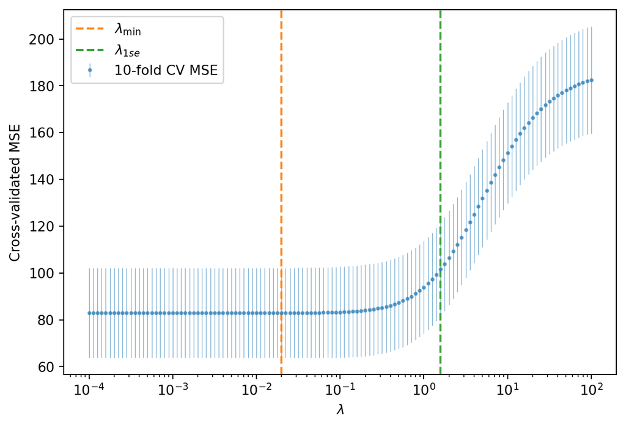

```python
fold_ids = sorted(train5["cv_fold"].dropna().unique())
fold_errors = np.zeros((len(fold_ids), len(lambdas5)))

for i, k in enumerate(fold_ids):
    is_val = train5["cv_fold"] == k
    tr, va = train5.loc[~is_val], train5.loc[is_val]
    mean_k, scale_k = standardize_fit(tr[predictors5].to_numpy())
    Xtr = (tr[predictors5].to_numpy() - mean_k) / scale_k
    Xva = (va[predictors5].to_numpy() - mean_k) / scale_k
    ytr, yva = tr["price"].to_numpy(), va["price"].to_numpy()
    ybar_k = ytr.mean()
    Beta_k, _ = ridge_beta_grid(Xtr, ytr - ybar_k, lambdas5)
    pred_va = ybar_k + Xva @ Beta_k
    fold_errors[i, :] = np.mean((yva[:, None] - pred_va) ** 2, axis=0)

mean_mse5 = fold_errors.mean(axis=0)
se5 = fold_errors.std(axis=0, ddof=1) / np.sqrt(len(fold_ids))

i_min = np.argmin(mean_mse5)
lambda_min = lambdas5[i_min]
threshold = mean_mse5[i_min] + se5[i_min]
lambda_1se = lambdas5[mean_mse5 <= threshold].max()

print("lambda_min:", round(lambda_min, 5), " mean CV MSE:", round(mean_mse5[i_min], 3),
      " SE:", round(se5[i_min], 3))
print("lambda_1se:", round(lambda_1se, 5), " mean CV MSE:",
      round(mean_mse5[lambdas5 == lambda_1se][0], 3))

plt.figure(figsize=(6.5, 4.5))
pos = lambdas5 > 0
plt.errorbar(lambdas5[pos], mean_mse5[pos], yerr=se5[pos], fmt="o", markersize=2,
             elinewidth=0.5, alpha=0.6, label="10-fold CV MSE")
plt.axvline(lambda_min, color="C1", linestyle="--", label=r"$\lambda_{\min}$")
plt.axvline(lambda_1se, color="C2", linestyle="--", label=r"$\lambda_{1se}$")
plt.xscale("log")
plt.xlabel(r"$\lambda$")
plt.ylabel("Cross-validated MSE")
plt.legend()
plt.tight_layout()
plt.show()
```

**Show the workflow**

```
lambda_gcv: 0.02818  GCV: 83.502
```

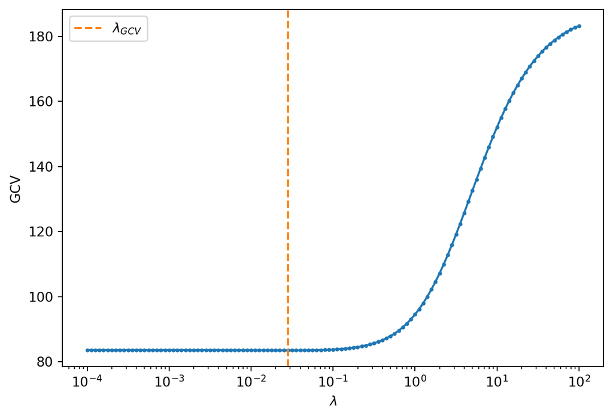

```python
mean_all, scale_all = standardize_fit(train5[predictors5].to_numpy())
Xtr_all = (train5[predictors5].to_numpy() - mean_all) / scale_all
ytr_all = train5["price"].to_numpy()
n_all = len(ytr_all)
ybar_all = ytr_all.mean()

Beta_all, d_all = ridge_beta_grid(Xtr_all, ytr_all - ybar_all, lambdas5)
fitted_all = ybar_all + Xtr_all @ Beta_all
mse_train_all = np.mean((ytr_all[:, None] - fitted_all) ** 2, axis=0)

df_eff5 = 1 + np.sum(
    d_all[:, None] ** 2 / (d_all[:, None] ** 2 + n_all * lambdas5[None, :]), axis=0
)
gcv = mse_train_all / (1 - df_eff5 / n_all) ** 2
lambda_gcv = lambdas5[np.argmin(gcv)]

print("lambda_gcv:", round(lambda_gcv, 5), " GCV:", round(gcv.min(), 3))

plt.figure(figsize=(6.5, 4.5))
plt.plot(lambdas5[pos], gcv[pos], marker="o", markersize=2)
plt.axvline(lambda_gcv, color="C1", linestyle="--", label=r"$\lambda_{GCV}$")
plt.xscale("log")
plt.xlabel(r"$\lambda$")
plt.ylabel("GCV")
plt.legend()
plt.tight_layout()
plt.show()
```

**Show the workflow**

```python
Xte = (test5[predictors5].to_numpy() - mean_all) / scale_all
yte = test5["price"].to_numpy()

chosen = {"OLS": 0.0, "lambda_min": lambda_min, "lambda_1se": lambda_1se, "lambda_gcv": lambda_gcv}
rows = []
for name, lam in chosen.items():
    idx = np.where(lambdas5 == lam)[0][0]
    beta = Beta_all[:, idx]
    train_mse = np.mean((ytr_all - (ybar_all + Xtr_all @ beta)) ** 2)
    test_mse = np.mean((yte - (ybar_all + Xte @ beta)) ** 2)
    rows.append((name, lam, df_eff5[idx], train_mse, test_mse))

summary5 = pd.DataFrame(rows, columns=["model", "lambda", "df_eff", "train_mse", "test_mse"])
summary5
```

|  | model | lambda | df_eff | train_mse | test_mse |
| --- | --- | --- | --- | --- | --- |
| 0 | OLS | 0.000000 | 7.000000 | 80.093917 | 66.322464 |
| 1 | lambda_min | 0.019953 | 6.773213 | 80.135429 | 65.999575 |
| 2 | lambda_1se | 1.584893 | 3.032870 | 100.373559 | 81.199810 |
| 3 | lambda_gcv | 0.028184 | 6.688657 | 80.171254 | 65.902765 |

## `explain-to-me` skill

```
explain-to-me/SKILL.md
```

```markdown
---
name: explain-to-me
description: Explains what one named homework question is asking - its goal, what's given, and what work is required - without writing or hinting at a solution. Use only when explicitly asked to use this skill to read and explain a specific homework question.
metadata:
  version: "1.0.0"
---

# explain-to-me

## Intent

Help me understand a homework question before I attempt it myself. Read the
question I point to and explain it back to me in plain language. Do not
solve it, do not write solution code or derivations, and do not state or
imply the final numeric or algebraic answer.

## Instructions

1. Read only the specific question (and any shared setup/preamble it
   depends on) that I name - not the other questions, and not any
   solutions file, even if one exists in the repository.
2. Explain, briefly:
   - What the question's overall goal is (what quantity, plot, derivation,
     or conclusion it wants me to produce).
   - What is given versus what I still need to do (e.g. "generate this
     data with this seed," "derive this formula," "report these specific
     numbers").
   - Any easy-to-miss requirement (a specific seed, a formula I must use,
     a report or comparison the question asks for).
3. If the question concerns ridge regression, point me to the relevant
   part of one or both Week 3 lecture pages:
   - [Ridge Regression: Stability Through Shrinkage](https://teazrq.github.io/stat432rpy/topics/ridge-regression/ridge-regression.html)
   - [From a Penalized Objective to a Fitted Ridge Model](https://teazrq.github.io/stat432rpy/topics/ridge-regression/optimization-and-cross-validation.html)
4. Never write the code, derivation, or final answer for the question. If
   I ask you to also solve it, decline within this skill and tell me to
   ask again without invoking `explain-to-me`.
5. Keep the explanation short - a few sentences or a short bullet list,
   not a rewritten copy of the whole question.

## Out of scope

Do not use this skill to grade, review, or improve my existing answers.
Do not use it on any question I have not explicitly named.
```

## Reference

The real-estate data come from I-Cheng Yeh’s [Real Estate Valuation dataset](https://archive.ics.uci.edu/dataset/477/real%2Bestate%2Bvaluation%2Bda) in the UCI Machine Learning Repository. The distributed data retain the original observations and add only the course train-test and fold assignments.